# Time Series Analysis of French Electricity Consumption: 2024-2025 Project

## 1. Introduction

This report details the analysis of monthly electricity consumption in France from January 2008 to March 2025. The primary objective is to develop a robust time series model capable of accurately forecasting future consumption.

The methodology follows the Box-Jenkins approach for building a Seasonal Autoregressive Integrated Moving Average (SARIMA) model. The process involves several key stages:

1. Exploratory Data Analysis: Initial visualization and decomposition of the data to understand its underlying structure, including trend and seasonality.
2. Data Transformation: Applying necessary transformations to stabilize the variance and stationarize the series.
3. Model Identification, Estimation, and Diagnostics: Proposing candidate SARIMA models based on the Autocorrelation Function (ACF) and Partial Autocorrelation Function (PACF), estimating model parameters, and performing rigorous diagnostic checks on the model’s residuals.
4. Forecasting and Accuracy Evaluation: Generating forecasts on a hold-out test set and evaluating their accuracy using standard metrics. 5.Results, Discussion and Conclusion: Compare the different results of the differnt models.

The dataset will be split into a training set for model building and a test set for forecast validation, as recommended.

## 2. Data and Exploratory Analysis

### Data Loading and Preparation

First, we load the necessary R libraries and the dataset. The data represents the monthly electricity available to the internal market in France, measured in Gigawatt-hours (GWh).

```r
#install.packages(c("forecast", "urca", "lmtest", "tseries", "ggplot2", "MuMIn", "kableExtra"))
library(MuMIn)
library(forecast)
library(urca)
library(lmtest)
library(tseries)
library(ggplot2)
library(kableExtra)


# Load the data
dados <- read.csv("data/data2.csv")

# Create a time series object
# The data is monthly (frequency=12) and starts in January 2008.
ts_data <- ts(dados$OBS_VALUE, start = c(2008, 1), frequency = 12)
names(dados)
```

```
##  [1] "STRUCTURE"
##  [2] "STRUCTURE_ID"
##  [3] "STRUCTURE_NAME"
##  [4] "freq"
##  [5] "Time.frequency"
##  [6] "nrg_bal"
##  [7] "Energy.balance"
##  [8] "siec"
##  [9] "Standard.international.energy.product.classification..SIEC."
## [10] "unit"
## [11] "Unit.of.measure"
## [12] "geo"
## [13] "Geopolitical.entity..reporting."
## [14] "TIME_PERIOD"
## [15] "Time"
## [16] "OBS_VALUE"
## [17] "Observation.value"
## [18] "OBS_FLAG"
## [19] "Observation.status..Flag..V2.structure"
## [20] "CONF_STATUS"
## [21] "Confidentiality.status..flag."
```

```r
head(dados)
```

```
##   STRUCTURE         STRUCTURE_ID
## 1  dataflow ESTAT:NRG_CB_EM(1.0)
## 2  dataflow ESTAT:NRG_CB_EM(1.0)
## 3  dataflow ESTAT:NRG_CB_EM(1.0)
## 4  dataflow ESTAT:NRG_CB_EM(1.0)
## 5  dataflow ESTAT:NRG_CB_EM(1.0)
## 6  dataflow ESTAT:NRG_CB_EM(1.0)
##                                                         STRUCTURE_NAME freq
## 1 Supply, transformation and consumption of electricity - monthly data    M
## 2 Supply, transformation and consumption of electricity - monthly data    M
## 3 Supply, transformation and consumption of electricity - monthly data    M
## 4 Supply, transformation and consumption of electricity - monthly data    M
## 5 Supply, transformation and consumption of electricity - monthly data    M
## 6 Supply, transformation and consumption of electricity - monthly data    M
##   Time.frequency nrg_bal               Energy.balance  siec
```

[output cut: 34 more lines]

### Exploratory Analysis

To study the existence of outliers we can use a boxplot.

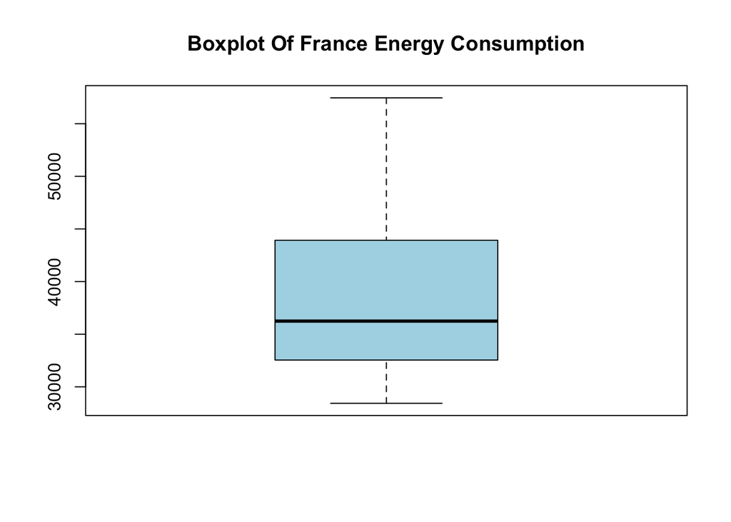

```r
dados$OBS_VALUE <- as.numeric(gsub(",", ".", dados$OBS_VALUE))
boxplot(dados$OBS_VALUE, main = "Boxplot Of France Energy Consumption", col = "lightblue")
```

As we can observe, the box plot shows us that we do not have outliers.

We begin by plotting the time series to visually inspect its components.

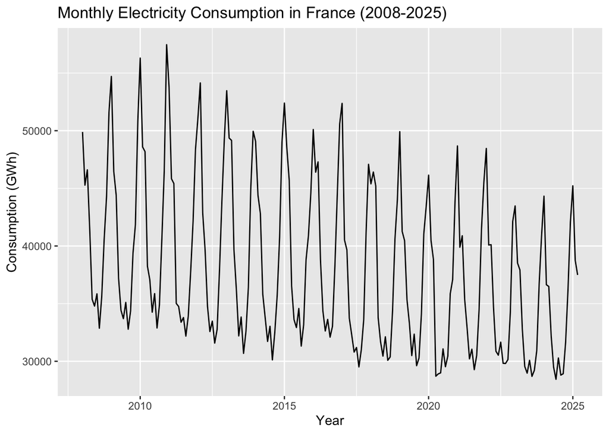

```r
autoplot(ts_data,
         ylab = "Consumption (GWh)",
         xlab = "Year",
         main = "Monthly Electricity Consumption in France (2008-2025)")
```

The plot reveals two key characteristics:

1. Strong Seasonality: There is a clear and repeating annual pattern, with consumption peaking in the winter months and reaching a low in the summer.
2. Trend: There appears to be a slight downward trend in consumption over the years, particularly after 2010.
3. Varience: It seems that the variance also varies a little bit, specially comparing the earlier years with the older ones. To better visualize these components, we decompose the series.

### Data Splitting

To properly evaluate our model’s forecasting ability, we split the data into a training set (80% of the data) for model fitting and a test set (the remaining 20%) for validation.

```r
# Split data: 80% for training, 20% for testing
n <- length(ts_data)
train_size <- floor(0.8 * n)
ts_train <- window(ts_data, end = time(ts_data)[train_size])
ts_test <- window(ts_data, start = time(ts_data)[train_size + 1])

cat("Training set length:", length(ts_train), "observations\n")
```

```
## Training set length: 165 observations
```

```r
cat("Test set length:", length(ts_test), "observations\n")
```

```
## Test set length: 42 observations
```

We will only apply the transformations to the training set (and repeat in the test when necessary) to avoid data leakage.

We opted for classical decomposition rather than STL, since the trend and seasonality are clear and stable.

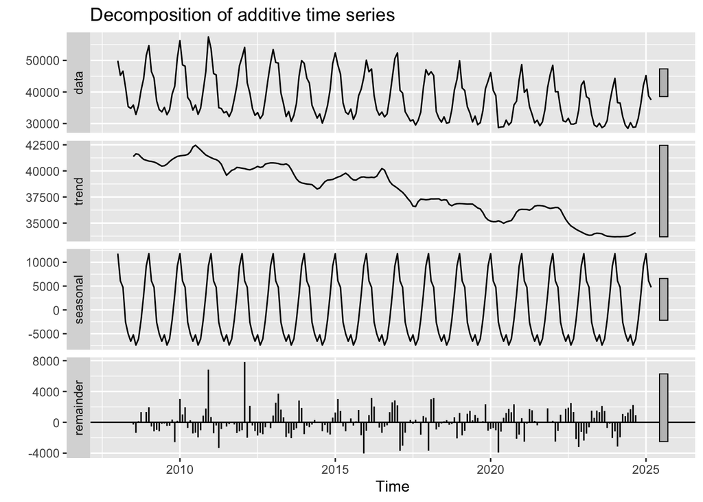

```r
# Decompose the series to show trend, seasonality, and remainder
decomposed <- decompose(ts_data)
autoplot(decomposed)
```

The decomposition confirms the strong seasonal pattern and a visible, though somewhat noisy, trend.

### Stationarity Assessment

To stabilize the variance, we should apply a log transformation. Visually, the series shows more intense seasonal variation at higher values (2008-2012), and then less over time. This indicates that the variance depends on the level of the series, which justifies the use of log().

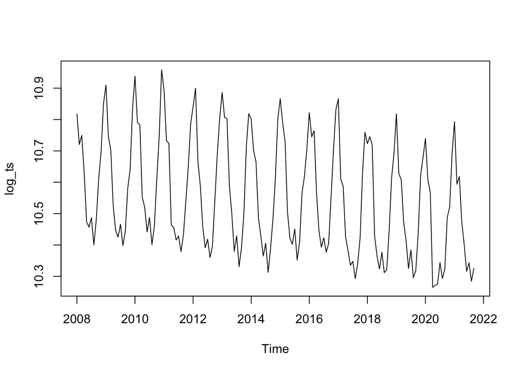

```r
log_ts <- log(ts_train)
plot(log_ts)
```

We already now that the trend is not constant just by observing the time series plot. However, we will do some stacionarity tests with ADF e KPSS to check if we do need to differenciate the time series. We can confirm this with statistical tests.

- Augmented Dickey-Fuller (ADF) Test: Null hypothesis
  $$H_0$$
  is that the series is non-stationary.
- KPSS Test: Null hypothesis
  $$H_0$$
  is that the series is stationary.

```r
# ADF test on the training data
adf.test(log_ts)
```

```
##
##  Augmented Dickey-Fuller Test
##
## data:  log_ts
## Dickey-Fuller = -9.89, Lag order = 5, p-value = 0.01
## alternative hypothesis: stationary
```

```r
# KPSS test on the training data
kpss.test(log_ts)
```

```
##
##  KPSS Test for Level Stationarity
##
## data:  log_ts
## KPSS Level = 0.53416, Truncation lag parameter = 4, p-value = 0.03397
```

The ADF test’s low p-value (< 0.05) means we can reject
$$H_0$$
, suggesting stationarity. The KPSS test’s low p-value (< 0.05) leads us to reject
$$H_0$$
, indicating non-stationarity.

We have an ambiguous situation, assuming that the series is not yet fully stationary, it is safer to differentiate the series.

### Achieving Stationarity through Differencing

we use the ndiffs() and nsdiffs() functions from the forecast package to determine how many differentiations are needed to make the logarithmically transformed series (log_ts) stationary.

```r
# library(forecast)
ndiffs(log_ts)     # trend
```

```
## [1] 1
```

```r
nsdiffs(log_ts)    # sazonality
```

```
## [1] 1
```

To make the series stationary, we apply differencing. Given the strong 12-month seasonality, we start with seasonal differencing (lag=12).

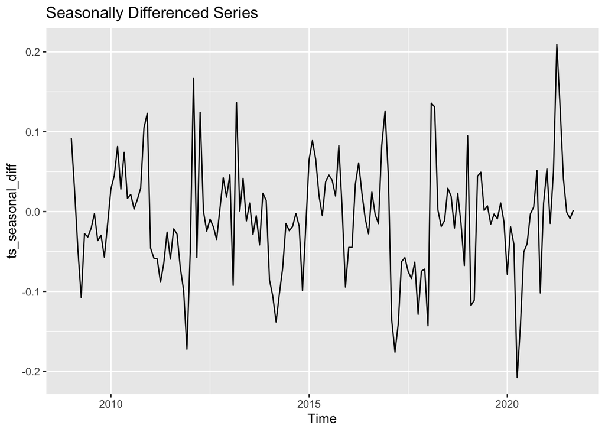

```r
# Apply seasonal differencing (D=1)
ts_seasonal_diff <- diff(log_ts, lag = 12)
autoplot(ts_seasonal_diff, main = "Seasonally Differenced Series")
```

The seasonal pattern is gone, but a trend might still be present. We now apply a regular first difference to remove any remaining trend.

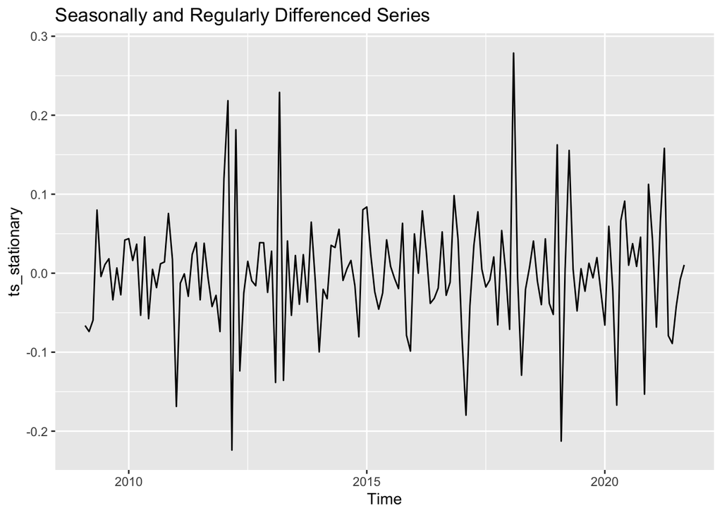

```r
# Apply regular differencing to the seasonally differenced series (d=1)
ts_stationary <- diff(ts_seasonal_diff, differences = 1)
autoplot(ts_stationary, main = "Seasonally and Regularly Differenced Series")
```

This series appears stationary. Let’s re-run the tests to confirm.

```r
adf.test(ts_stationary)
```

```
##
##  Augmented Dickey-Fuller Test
##
## data:  ts_stationary
## Dickey-Fuller = -8.1083, Lag order = 5, p-value = 0.01
## alternative hypothesis: stationary
```

```r
kpss.test(ts_stationary)
```

```
##
##  KPSS Test for Level Stationarity
##
## data:  ts_stationary
## KPSS Level = 0.028599, Truncation lag parameter = 4, p-value = 0.1
```

After applying seasonal differencing (lag = 12) and a first regular difference, we re-evaluated the series for stationarity. The Augmented Dickey-Fuller (ADF) test strongly rejected the null hypothesis of non-stationarity (p < 0.01), and the KPSS test failed to reject the null of stationarity (p > 0.1). These results confirm that the differenced series is stationary.

### Study of ACF/PACF functions

The ACF and PACF must be analysed in the stationary series that will be modelled - that is, after applying the necessary transformations and differentiations. They are basic tools for analysing time series and helping to choose models (such as ARIMA).

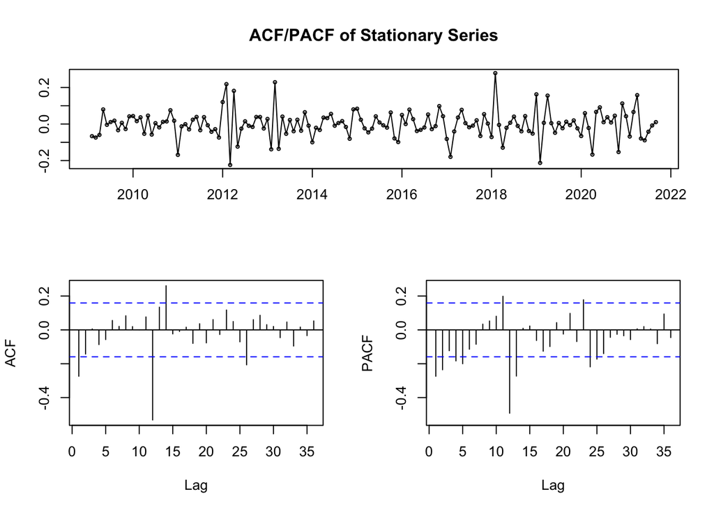

```r
# ACF/PACF on log series
# acf(log_ts, main="CF of log-transformed series")
# pacf(log_ts, main="PACF of log-transformed series")

# ACF/PACF on diffenciated series
# acf(ts_stationary, main="ACF of the log-transformed series and differentiated 2 times")
# pacf(ts_stationary, main="PACF of the log-transformed and 2-fold differentiated series")

tsdisplay(ts_stationary, main="ACF/PACF of Stationary Series")
```

- Seasonal Order (P, Q): At the seasonal lag 12, the ACF has a significant negative spike, and the PACF cuts off afterward. This suggests a seasonal MA(1) model, so we set Q=1 and P=0. - Non-Seasonal Order (p, q): In the non-seasonal lags, the ACF has a significant spike at lag 1 and the PACF has a significant spike at lag 1. This could suggest either an AR(1) or MA(1) model. Based on this, a good candidate model is SARIMA(p,1,q)(0,1,1)[12]. We’ll let auto.arima() find the optimal p and q values.

## 3. Model Proposal and Diagnostics

### Model Identification and Estimation

We will create different models in order to compare methodologies for scientific purposes. Since the time series has many characteristics, it is important to use different models. The purpose of this project is to compare different approaches and select the best-fitting model without overfitting. To achieve this, we will compare the adjustment of point 3 to the accuracy values of point 4 to find the optimal balance between the two.

#### 3.1. Auto Arima

Since we are going to carry out forecasting later, we have divided our data into training and test sets. The models will only be fitted and modelled using the training set, and we will then be able to test and evaluate the forecasts.

```r
# Fit model using auto.arima on the training data
auto_fit <- auto.arima(ts_train, stepwise = FALSE, approximation = FALSE)
summary(auto_fit)
```

```
## Series: ts_train
## ARIMA(1,0,0)(0,1,2)[12] with drift
##
## Coefficients:
##          ar1     sma1    sma2     drift
##       0.3712  -1.0536  0.1825  -38.3646
## s.e.  0.0769   0.0987  0.1008    4.5860
##
## sigma^2 = 3551888:  log likelihood = -1378.82
## AIC=2767.64   AICc=2768.05   BIC=2782.8
##
## Training set error measures:
##                    ME     RMSE      MAE       MPE     MAPE     MASE        ACF1
## Training set 107.0486 1790.939 1231.609 0.1500579 3.025571 0.566978 -0.02814851
```

Next, we perform diagnostic checks on the model’s residuals to ensure they behave like white noise (i.e., are random and uncorrelated).

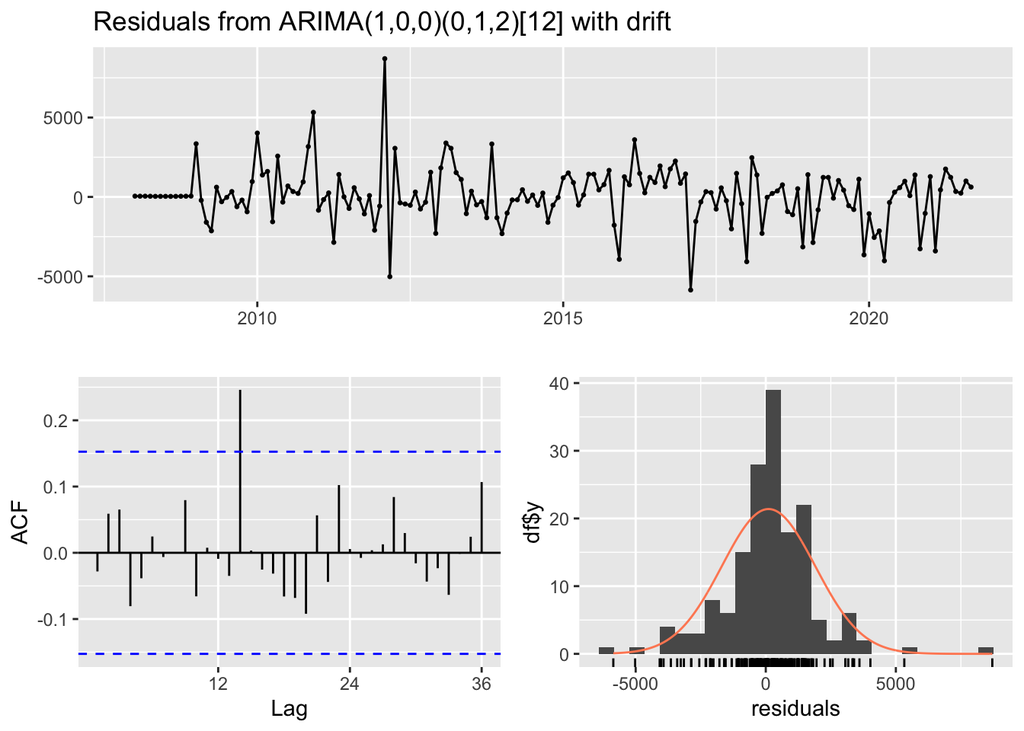

```
##
##  Ljung-Box test
##
## data:  Residuals from ARIMA(1,0,0)(0,1,2)[12] with drift
## Q* = 22.728, df = 21, p-value = 0.3586
##
## Model df: 3.   Total lags used: 24
```

```r
# Perform residual diagnostics
checkresiduals(auto_fit)
```

The diagnostic plots show:

- The residuals plot shows no obvious patterns, appearing random around a mean of zero.
- The ACF plot of residuals have only one significant spikes which means in general there is no correlation between the residuals.
- The Ljung-Box test has a large p-value (0.35), meaning we cannot reject the null hypothesis that the residuals are independently distributed. The model successfully passes the diagnostic checks, since the residuals behave like white noise, without patterns and non-autocorrelated.